# The Effects of Highways on Guanaco Movement in Patagonia

## Introduction

Animal movement is integral for the transportation of nutrients, plant productivity, and other ecosystem functions. Anthropogenic disturbances such as urban developments and energy production greatly affect animals’ daily movements, migration patterns, and access to necessary resources. As human populations grow, it is important to analyze and identify how barriers, such as roads, will affect animal movements. There is a great deal of variation on wildlife response to roads and ungulates are among the more affected species. While there has been considerable research about the impacts of roads on ungulates throughout North America and Europe, there has been comparatively little research how roads impact South American wildlife.

## Research Questions

How does highway traffic constrain guanaco movement? Do guanacos respond differently to roads with varying traffic volumes?

To analyze the effects of traffic, I compared guanaco interactions with the main highway as well as two additional roads that differ in traffic intensity: a visitor road that connects the highway to the park and smaller, unpaved roads used by park staff.

## Hypotheses and Predictions

I hypothesize that guanaco movement will be impacted by the highway and that guanancos will avoid crossing roads with high traffic.

- Guanacos will be more likely to cross the highway during the day because they are diurnal.
- Female guanacos will be less likely to cross the highway because they have chulengos (baby guanacos).

To further test these hypotheses and predictions, I examined whether differences in guanaco behavior between the highway and visitor roads are greater during the daytime, when vehicular traffic is higher, than at night, when traffic is lower.

This will show if guanacos are not crossing the highway due to the concrete or lack of cover vs traffic, since concrete and lack of cover do not change during the night.

## Study Area

Monte León National Park (MLNP)

- 61,000 ha along 30 km of coastline in the Patagonian Steppe
- Bounded by Route 3 and the Atlantic Ocean

Highway: A two lane road that extends from Buenos Aires to the tip of Argentina, making it a major transportation route for the country with high volumes of traffic.

Visitors Road: A two lane road that takes tourists from the highway to the ocean through MLNP.

Park Use Roads: A dirt road system used only by park officials.

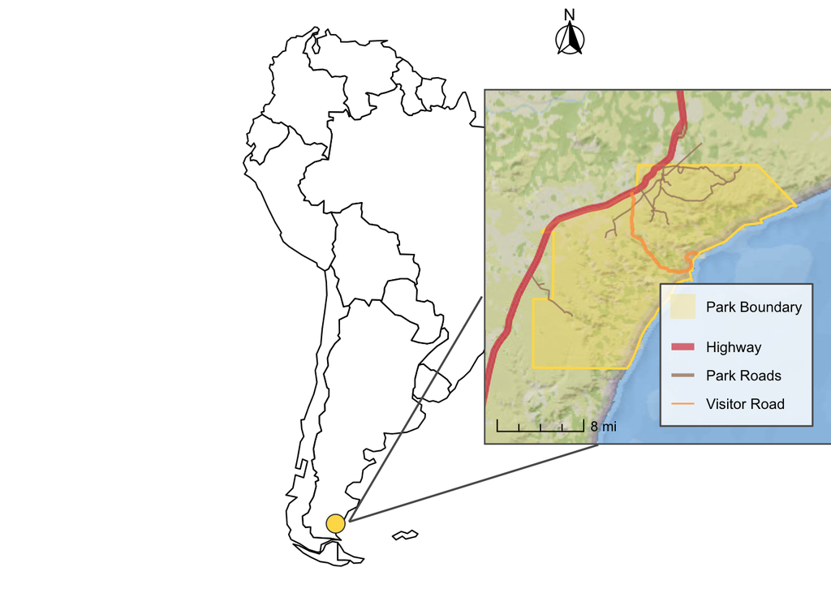

## Model

To analyze guanacos’ interaction with the roads I used Barrier Behavior Analysis (BaBA) a spatial analysis package that classifies barrier interaction types.

- I assumed that if the guanaco is using the habitat equally there will be a 50% chance it crosses an arbitrary barrier.

$H_0: \beta_{highway} = \beta_{visitor} = \beta_{park\ roads} = 0.5$

$H_A: \beta_{highway} < \beta_{visitor} \text{ and } \beta_{highway} < \beta_{park\ roads}$

## Results

### Exploratory Findings

- 66.4% of highway crossings occurred during the summer months (p < 0.05)
- 64.7% of highway crossings occurred during daytime.
- 29.3% of highway crossing events were by male guanacos (p < 0.05), indicating that females were more likely to cross.

These results contrast with my initial prediction that female guanacos would be less likely to cross the highway. One possible explanation is that females may travel in larger groups, increasing their likelihood of crossing, whereas males are more solitary and potentially less bold. Further investigation is needed to better understand these behavioral patterns.

### Figure 1: Differences in Road Crossings

**Sex**

[interactive chart not shown]

**Time of Day**

[interactive chart not shown]

**Season**

[interactive chart not shown]

Note: Guanaco data collection occurred October 2019 through November 2021.

10 of the 4668 interactions were classified as “Quick Cross”, meaning that only 10 of the 116 highway crosses took place within 2 hours of being 80 meters from the highway.

### Guanaco Behavioral Responses

Summary Statistics with Highway as Barrier

| Interaction Type | Number of Interactions | Share of Interactions | Share Leading to Cross |
| --- | --- | --- | --- |
| Average Movement | 971 | 20.8% | 5.1% |
| Trapped | 1,802 | 38.6% | 0.4% |
| Bounce | 1,051 | 22.5% | 0.0% |
| Quick Cross | 10 | 0.2% | 100.0% |

## Model Results

To test whether guanacos avoid crossing the highway due to traffic, I created two interaction variables combining the highway and visitor roads with a daytime binary variable. The coefficients on these interaction terms capture the additional impact of crossing busy roads, using daytime as a proxy for higher traffic.

### Model Comparison (AIC Values)

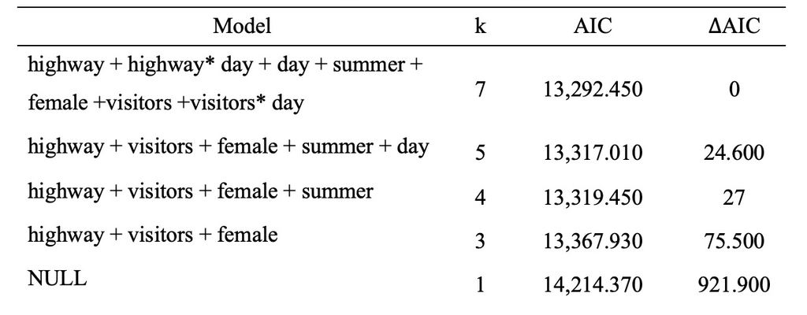

When these interactions are included, we find that guanacos are 7.4% and 7.7% less likely to cross the highway and visitor road, respectively, beyond the baseline likelihood of crossing during the day. This reduction is likely attributable to traffic-related avoidance or increased perceived risk. Notably, this model is the most explanatory, as it has the lowest AIC value among those tested.

My results indicated that paved roads significantly affect guanaco movement, with vehicular traffic being a major contributing factor. However, other factors may also influence highway avoidance, including differences in vegetation and habitat on either side of the road, as well as fear of poaching, since private land borders the highway. Future research should investigate these alternative hypotheses and the potential role of fencing.

### Regression Table

[interactive chart not shown]

This study builds on the idea that roads affect guanacos use of space negatively by finding a mechanistic answer: guanacos fear traffic. I can conclude that guanacos do not exhibit fear from being close to roads, but the road acts as a barrier for crossing.

This has huge conservation implications since roads may lead to spatial segregation and isolation of guanaco populations. In North America and Europe, we have seen the creation of wildlife tunnels and bridges for animals crossing major roads, and this could be a potential mitigation technique in South America. Strategies such as these allow for increased permeability of an otherwise uncrossable barrier.

The Patagonian steppe is considered a high priority location for global conservation due to habitat fragmentation. There are currently lots of efforts to restore guanaco habitat. Organizations such as Tompkins Conservation (also known as Rewilding Patagonia) have been taking actions, such as buying and setting aside conservation tracts, to help protect habitat and species, since much of the area has become farmland. Another strategy for guanaco conservation is reintroducing guanacos throughout Argentina. When deciding locations of conservation tracts or where to release guanacos it is important to consider their mobility. All these conservation approaches will require huge investments so it is crucial to assess if roads in the area will limit guanacos’ ability to move between parks or conservation tracts.